# Fundamentos de Pesquisa em Ciência da Computação 2

Lab 3 - Checkpoint 4

23 de maio de 2018

## **Inferência Estatística baseada em Teste de Hipóteses aplicada às Sessões, Buscas e Navegação na Wikimedia**

Neste relatório, apresentam-se conclusões baseadas em inferência estatística sobre o *dataset* search_data.scv (extraído de https://meta.wikimedia.org/wiki/Schema:TestSearchSatisfaction2).

As seções iniciais deste relatório descrevem as bibliotecas utilizadas e os procedimentos para a importação do *dataset*. Na seção 3, explana-se o processo de teste de hipóteses com permutação, para as questões seguintes:

- A taxa diária de *clickthrough* varia entre os grupos A e B?  
  Pergunta relacionada ao questionamento “Qual é taxa diária de *clickthrough*? Como isso varia entre os grupos A e B?”
- A taxa diária de zero resultados varia entre os grupos A e B?  
  Pergunta relacionada ao questionamento “Qual é taxa diária de zero resultados? Como isso varia entre os grupos A e B?”

A seção 4 apresenta uma conclusão geral enfatizando as vantagens/desvantagens, em termos dos resultados obtidos, da utilização de teste de hipóteses e intervalos de confiança (Lab3 - *Checkpoint* 1).

### **1. Bibliotecas Utilizadas**

```r
library(tidyverse)
library(here)
library(lubridate)
library(summarytools)
library(boot)
library(resample) ##para permutação e cálculo do p-valor
library(GGally) ##extends 'ggplot2' by adding several functions to reduce the complexity of combining geometric objects with transformed data
theme_set(theme_bw())
```

### **2. Importação dos Dados**

```r
buscas_original = read_csv(here::here("data/search_data.csv"))
glimpse(buscas_original) ##visualizando as observações pré-filtragens
```

```
## Observations: 136,234
## Variables: 8
## $ session_id              <chr> "0000cbcb67c19c45", "0001382e027b2ea4"...
## $ search_index            <int> 1, 1, 1, 1, 2, 3, 4, 5, 6, 1, 1, 2, 1,...
## $ session_start_timestamp <dbl> 2.016030e+13, 2.016031e+13, 2.016031e+...
## $ session_start_date      <dttm> 2016-03-03 15:20:45, 2016-03-07 08:49...
## $ group                   <chr> "b", "b", "b", "a", "a", "a", "a", "a"...
## $ results                 <int> 20, 18, 20, 20, 20, 20, 20, 20, 20, 1,...
## $ num_clicks              <int> 0, 1, 1, 0, 0, 0, 0, 0, 0, 0, 0, 1, 0,...
## $ first_click             <int> NA, 1, 1, NA, NA, NA, NA, NA, NA, NA, ...
```

A partir da tabela, nota-se que há 136.234 observações.

### **3. Processo de Teste de Hipóteses**

Os seguintes passos são propostos para a realização dos testes de hipóteses para as questões 3.1 e 3.2:

- Estabelecimento das hipóteses nula (H<sub>0</sub>) e alternativa (H<sub>1</sub>);
- Determinação do nível de significância do teste (α);
- Cálculo da estatística de teste a partir das observações;
- Cálculo do p-valor;
- Interpretação dos resultados obtidos.

#### **3.1 A taxa diária de *clickthrough* varia entre os grupos A e B?**

##### **Estabelencendo as hipóteses nula e alternativa**

- H<sub>0</sub>: A categoria do grupo (A ou B) não influencia a taxa diária de *clickthrough*
- H<sub>1</sub>: A categoria do grupo influencia a taxa diária de *clickthrough*

##### **Determinando o nível de significância do teste**

Neste relatório, considera-se um nível de confiança (γ) de 0,95, isto é, 95% de probabilidade de não rejeitar a hipótese nula, quando ela é verdadeira. Sendo assim, o nível de significância é 0,05 (γ = 1 - α), o que representa a probabilidade de 5% de rejeitar a hipótese nula quando esta for verdadeira.

##### **Calculando a estatística de teste**

A **média** das taxas diárias de *clickthrough* é a estatística considerada para fins de inferência estatística. A figura 1 exibe a distribuição de taxas de *clickthrough* por data de ocorrência e grupo. Em seguida, a média de taxas de clickthrough diária por grupo é calculada.

```r
buscas1 = buscas_original %>%
  filter(results > 0) ##porque devem ser consideradas apenas buscas que geraram resultados para fins de análise
glimpse(buscas1) ##visualizando as observações pós-filtragem
```

```
## Observations: 111,107
## Variables: 8
## $ session_id              <chr> "0000cbcb67c19c45", "0001382e027b2ea4"...
## $ search_index            <int> 1, 1, 1, 1, 2, 3, 4, 5, 6, 1, 2, 1, 1,...
## $ session_start_timestamp <dbl> 2.016030e+13, 2.016031e+13, 2.016031e+...
## $ session_start_date      <dttm> 2016-03-03 15:20:45, 2016-03-07 08:49...
## $ group                   <chr> "b", "b", "b", "a", "a", "a", "a", "a"...
## $ results                 <int> 20, 18, 20, 20, 20, 20, 20, 20, 20, 1,...
## $ num_clicks              <int> 0, 1, 1, 0, 0, 0, 0, 0, 0, 0, 1, 0, 3,...
## $ first_click             <int> NA, 1, 1, NA, NA, NA, NA, NA, NA, NA, ...
```

```r
sessions_by_date_and_group = buscas1 %>%
  group_by(date = date(session_start_date), group) %>%       ##agrupando por data da ocorrência da sessão e por grupo
  summarize(total_sessions_by_date = n(),
            total_sessions_with_clicks_by_date = sum(num_clicks > 0),
            rate = (total_sessions_with_clicks_by_date/total_sessions_by_date) * 100)

names(sessions_by_date_and_group)[1]<-"date" ##renomeando a primeira coluna

glimpse(sessions_by_date_and_group)
```

```
## Observations: 16
## Variables: 5
## $ date                               <date> 2016-03-01, 2016-03-01, 20...
## $ group                              <chr> "a", "b", "a", "b", "a", "b...
## $ total_sessions_by_date             <int> 10232, 4695, 10685, 4628, 1...
## $ total_sessions_with_clicks_by_date <int> 3669, 693, 3757, 719, 3929,...
## $ rate                               <dbl> 35.85809, 14.76038, 35.1614...
```

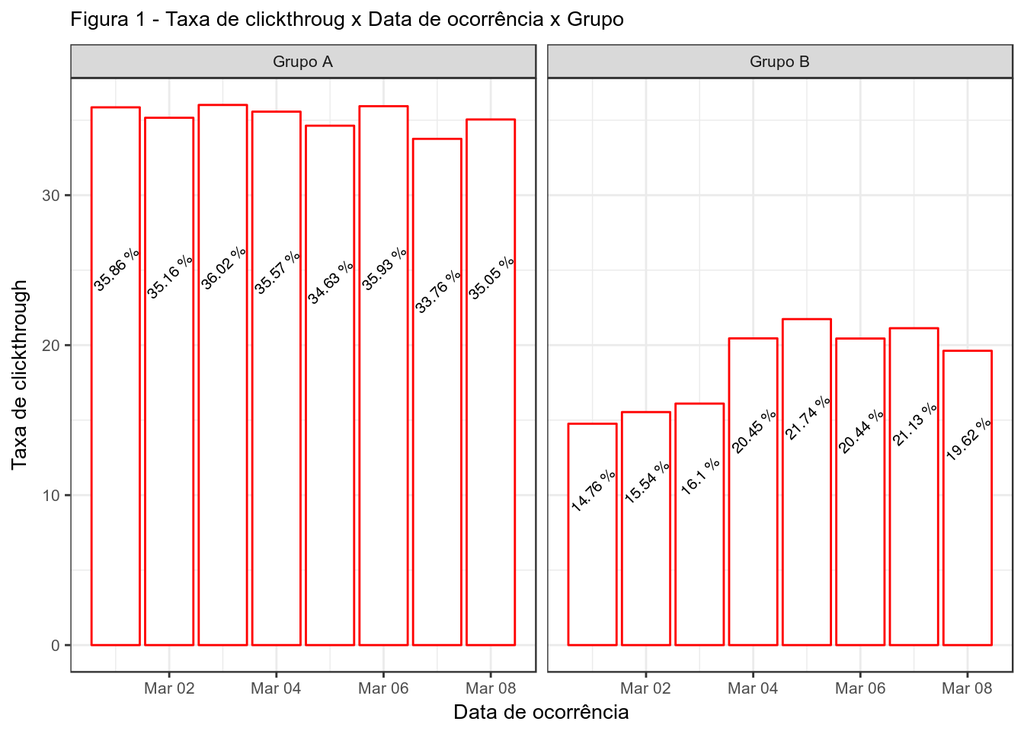

```r
group_names <- c('a' = "Grupo A", 'b' = "Grupo B")
sessions_by_date_and_group %>%
    ggplot(aes(y = rate, x = date)) +
    ggtitle("Figura 1 - Taxa de clickthroug x Data de ocorrência x Grupo") +
    geom_bar(stat = "identity", fill = "white", color = "red") +
    geom_text(aes(label = paste(round(rate, digits = 2), "%")), angle = 45, position = position_stack(vjust = .7), size = 2.7) +
    ylab("Taxa de clickthrough") +
    xlab("Data de ocorrência") +
    theme(text = element_text(family = "Arial", size = 10), plot.title = element_text(size = 10), axis.title.x = element_text(size = 10), axis.title.y = element_text(size = 10)) +
    facet_grid(.~group, labeller = as_labeller(group_names))
```

```r
##Calculando a estatística para os grupos
mean_group_function <- function(data, g){
  group_g = filter(data, group == eval(parse(text = "g")))  ##funciona também com group == x
  mean_rate_of_sessions_with = mean(group_g$rate)
}

print(mean_group_function(sessions_by_date_and_group, "a"))
```

```
## [1] 35.24709
```

```r
print(mean_group_function(sessions_by_date_and_group, "b"))
```

```
## [1] 18.7228
```

Em média, para o grupo A, em 35,25% das sessões diárias, os usuários clicam em algum resultado de busca e, para o grupo B, em 18,72%.

##### **Calculando o p-valor**

```r
##sessions_by_date armazena as taxas diárias de *clickthough*
rates_by_group = sessions_by_date_and_group %>%
  select(group, rate) ##selecionando apenas estas variáveis para o cálculo do p-valor com permutação

glimpse(rates_by_group)
```

```
## Observations: 16
## Variables: 3
## $ date  <date> 2016-03-01, 2016-03-01, 2016-03-02, 2016-03-02, 2016-03...
## $ group <chr> "a", "b", "a", "b", "a", "b", "a", "b", "a", "b", "a", "...
## $ rate  <dbl> 35.85809, 14.76038, 35.16144, 15.53587, 36.01613, 16.101...
```

```r
##efetuando o cálculo do p-valor
permutationTest2(rates_by_group, mean(rate), treatment = group)
```

```
## Call:
## permutationTest2(data = rates_by_group, statistic = mean(rate),
##     treatment = group)
## Replications: 9999
## Two samples, sample sizes are 8 8
##
## Summary Statistics for the difference between samples 1 and 2:
##                 Observed       Mean Alternative PValue
## mean(rate): a-b 16.52429 -0.0552035   two.sided  2e-04
```

O p-valor calculado é 0,0002.

##### **Interpretando o resultado obtido**

Dado que o p-valor calculado (0,0002) é menor que o nível de significância (α = 0,05), conclui-se que o resultado é estatisticamente significativo, pois o erro (0,02%) está dentro do limite fixado (p-valor < α). Portanto, a hipótese nula “A categoria do grupo (A ou B) não influencia a taxa diária de *clickthrough*” é rejeitada.

#### **3.2 A taxa diária de zero resultados varia entre os grupos A e B?**

##### **Estabelencendo as hipóteses nula e alternativa**

- H<sub>0</sub>: A categoria do grupo (A ou B) não influencia a taxa diária de zero resultados
- H<sub>1</sub>: A categoria do grupo influencia a taxa diária de zero resultados

##### **Determinando o nível de significância do teste**

Considera-se um nível de significância igual a 0,05 (α = 0,05), representando a probabilidade de 5% de rejeitar a hipótese nula quando esta for verdadeira.

##### **Calculando a estatística de teste**

A **média** das taxas diárias de zero resultados é a estatística considerada para fins de inferência estatística. A figura 2 exibe a distribuição de taxas por data de ocorrência e grupo. Em seguida, a média de taxas diárias de zero resultados por grupo é calculada.

```r
buscas2 = buscas_original %>%
  filter(!is.na(results)) ##porque apenas resultados válidos (0 e diferente de 0) deve ser considerado

glimpse(buscas2) ##visualizando as observações pós-filtragem
```

```
## Observations: 136,234
## Variables: 8
## $ session_id              <chr> "0000cbcb67c19c45", "0001382e027b2ea4"...
## $ search_index            <int> 1, 1, 1, 1, 2, 3, 4, 5, 6, 1, 1, 2, 1,...
## $ session_start_timestamp <dbl> 2.016030e+13, 2.016031e+13, 2.016031e+...
## $ session_start_date      <dttm> 2016-03-03 15:20:45, 2016-03-07 08:49...
## $ group                   <chr> "b", "b", "b", "a", "a", "a", "a", "a"...
## $ results                 <int> 20, 18, 20, 20, 20, 20, 20, 20, 20, 1,...
## $ num_clicks              <int> 0, 1, 1, 0, 0, 0, 0, 0, 0, 0, 0, 1, 0,...
## $ first_click             <int> NA, 1, 1, NA, NA, NA, NA, NA, NA, NA, ...
```

```r
sessions_by_date_and_group = buscas2 %>%
  group_by(date = date(session_start_date), group) %>%       ##agrupando por data da ocorrência da sessão e por grupo
  summarize(total_sessions_by_date = n(),
            total_sessions_with_zero_results_by_date = sum(results == 0),
            rate = (total_sessions_with_zero_results_by_date/total_sessions_by_date) * 100)

names(sessions_by_date_and_group)[1] <-"date" ##renomeando a primeira coluna

glimpse(sessions_by_date_and_group)
```

```
## Observations: 16
## Variables: 5
## $ date                                     <date> 2016-03-01, 2016-03-...
## $ group                                    <chr> "a", "b", "a", "b", "...
## $ total_sessions_by_date                   <int> 12582, 5792, 13209, 5...
## $ total_sessions_with_zero_results_by_date <int> 2350, 1097, 2524, 106...
## $ rate                                     <dbl> 18.67748, 18.93992, 1...
```

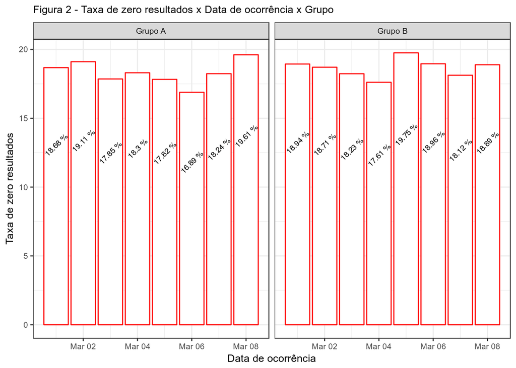

```r
group_names <- c('a' = "Grupo A", 'b' = "Grupo B")
sessions_by_date_and_group %>%
    ggplot(aes(y = rate, x = date)) +
    ggtitle("Figura 2 - Taxa de zero resultados x Data de ocorrência x Grupo") +
    geom_bar(stat = "identity", fill = "white", color = "red") +
    geom_text(aes(label = paste(round(rate, digits = 2), "%")), angle = 45, position = position_stack(vjust = .7), size = 2.7) +
    ylab("Taxa de zero resultados") +
    xlab("Data de ocorrência") +
    theme(text = element_text(family = "Arial", size = 10), plot.title = element_text(size = 10), axis.title.x = element_text(size = 10), axis.title.y = element_text(size = 10)) +
    facet_grid(.~group, labeller = as_labeller(group_names))
```

```r
print(mean_group_function(sessions_by_date_and_group, "a"))
```

```
## [1] 18.31291
```

```r
print(mean_group_function(sessions_by_date_and_group, "b"))
```

```
## [1] 18.65177
```

Em média, para o grupo A, em 18,31% das sessões diárias, há zero resultados de busca e, para o grupo B, em 18,65%.

##### **Calculando o p-valor**

```r
##sessions_by_date armazena as taxas diárias de zero resultados
rates_by_group = sessions_by_date_and_group %>%
  select(group, rate) ##selecionando apenas estas variáveis para o cálculo do p-valor com permutação

glimpse(rates_by_group)
```

```
## Observations: 16
## Variables: 3
## $ date  <date> 2016-03-01, 2016-03-01, 2016-03-02, 2016-03-02, 2016-03...
## $ group <chr> "a", "b", "a", "b", "a", "b", "a", "b", "a", "b", "a", "...
## $ rate  <dbl> 18.67748, 18.93992, 19.10818, 18.70718, 17.85392, 18.234...
```

```r
##efetuando o cálculo do p-valor
permutationTest2(rates_by_group, mean(rate), treatment = group)
```

```
## Call:
## permutationTest2(data = rates_by_group, statistic = mean(rate),
##     treatment = group)
## Replications: 9999
## Two samples, sample sizes are 8 8
##
## Summary Statistics for the difference between samples 1 and 2:
##                   Observed        Mean Alternative PValue
## mean(rate): a-b -0.3388582 0.002117914   two.sided  0.208
```

O p-valor calculado é aproximadamente 0,2.

##### **Interpretando o resultado obtido**

Dado que o p-valor calculado (0,2) é maior que o nível de significância (α = 0,05), conclui-se que o menor erro, que pode estar sendo cometido, ainda é maior que o erro máximo permitido (p-valor > α). Portanto, o resultado não é estatisticamente significativo, pois o risco de uma conclusão errada seria maior do que o quê se deseja assumir. A hipótese nula “A categoria do grupo (A ou B) não influencia a taxa diária de zero resultados” não é rejeitada.

### **4. Conclusões**

##### **Vantagens e desvantagens do p-valor x intervalos de Confiança**

Neste relatório, o p-valor foi calculado a partir de reamostragens baseadas em permutação não-pareada com 9.999 repetições. O teste de significância é bi-caudal (*two-tailed* ou *two-sided*), pois se considera que a diferença do parâmetro estimado (média), entre os grupos A e B, se desvia em qualquer direção das regiões de rejeição (vide Figura 3). Para melhor compreensão, note que cada região de aceitação compreende (1 - α) e a região de rejeição α/2, cada.

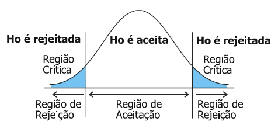

Figura 3 - Regiões de rejeição em teste bi-caudal - Fonte: https://stats.libretexts.org

O p-valor é um nível descrito associado ao teste de hipóteses e, portanto, não fornece magnitude de diferenças. Todo teste de hipótese possui erros associados; neste relatório, considerou-se apenas o erro do tipo I (também conhecido como nível de significância, expresso por α) que corresponde à probabilidade de concluir uma associação que não existe. Nesse contexto, o p-valor é definido como o menor nível de significância que pode ser assumido para a rejeição da hipótese nula.

Por outro lado, o intervalo de confiança representa a amplitude de valores que têm probabilidade (definida de acordo com o nível de confiança) de conter o verdadeiro valor da população. Sendo assim, de acordo com o nível de confiança é possível inferir conclusões a respeito da população.

Com isso em mente, seguem conclusões específicas para as perguntas investigadas.

#### **4.1 Conclusões baseadas em p-valor *vs* intervalo de confiança - A taxa diária de *clickthrough* varia entre os grupos A e B?**

- p-valor calculado: 0,0002 (< 0,05), com 95% de confiança, infere-se que há diferenças entre as taxas diárias de clickthrough dos grupos A e B para a população, mas não se quantifica tal diferença;
- intervalo de confiança: com 95% de confiança, afirma-se que o intervalo de confiança (14,05 a 24,61) contêm as verdadeiras diferenças entre os grupos (para a população). E, uma vez que este intervalo é positivo, conclui-se que há diferença estatisticamente significativa quanto às taxas diárias de *clickthrough* entre os grupos A e B. Infere-se, para a população, que as taxas do grupo A são maiores que as do grupo B. Seguem a distribuição amostral da diferença entre as médias das taxas diárias de *clickthrough* para os grupos A e B (Figura 4) e o intervalo de confiança calculado.

```r
set.seed(123)    ## semente 'aleatória' para a aleatoriedade de amostras

experimento1 = sample_n(buscas1, 1000)   ## obtém amostra de tamanho 1000
glimpse(experimento1)
```

```
## Observations: 1,000
## Variables: 8
## $ session_id              <chr> "49399bad821aa342", "c8e3738a2e91a397"...
## $ search_index            <int> 1, 1, 1, 1, 1, 1, 4, 3, 5, 7, 4, 6, 1,...
## $ session_start_timestamp <dbl> 2.016031e+13, 2.016030e+13, 2.016030e+...
## $ session_start_date      <dttm> 2016-03-08 14:28:59, 2016-03-02 13:11...
## $ group                   <chr> "a", "b", "b", "b", "b", "a", "a", "a"...
## $ results                 <int> 6, 7, 20, 1, 20, 20, 10, 16, 16, 6, 20...
## $ num_clicks              <int> 1, 0, 1, 0, 1, 0, 1, 0, 0, 0, 0, 0, 0,...
## $ first_click             <int> 1, NA, 1, NA, 1, NA, 2, NA, NA, NA, NA...
```

```r
bootstrap_group_function <- function(data, index){

  mean_rate_of_sessions_with_clicks_by_group = data %>%
      slice(index) %>%
      group_by(group, date(session_start_date)) %>%
      summarize(total_sessions_by_date = n(),
            total_sessions_with_clicks_by_date = sum(num_clicks > 0),
            rate = (total_sessions_with_clicks_by_date/total_sessions_by_date) * 100) %>%
      summarize(mean_rate = mean(rate)) %>%
      pull(mean_rate)

    return(mean_rate_of_sessions_with_clicks_by_group[1] - mean_rate_of_sessions_with_clicks_by_group[2])

}

bootstraps <- boot(experimento1, bootstrap_group_function, R = 2000)
glimpse(bootstraps$t)
```

```
##  num [1:2000, 1] 19.2 19.7 20.8 24.3 19.5 ...
```

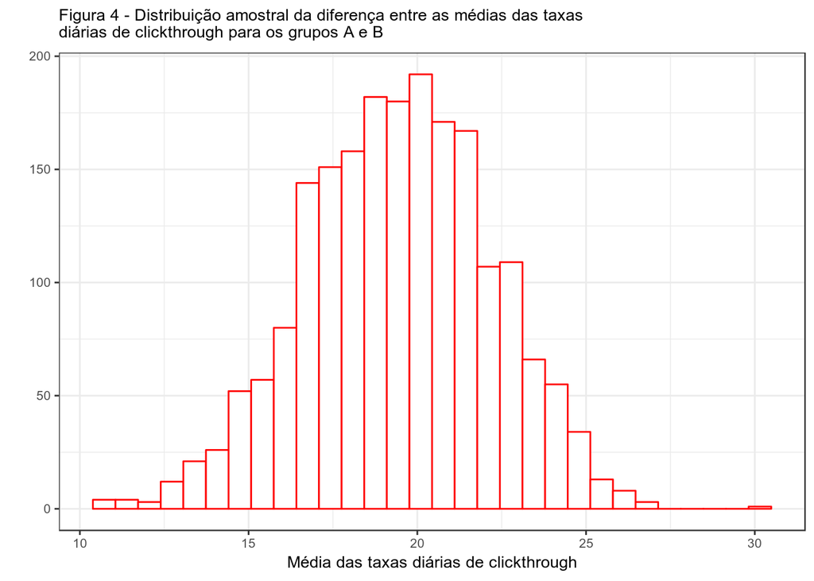

```r
tibble(estatistica = as.double(bootstraps$t)) %>%
  ggplot(aes(x = estatistica)) +
  geom_histogram(fill = "white", color = "red") +
  ggtitle("Figura 4 - Distribuição amostral da diferença entre as médias das taxas\ndiárias de clickthrough para os grupos A e B") +
  ylab(" ") +
  xlab("Média das taxas diárias de clickthrough") +
  theme(text = element_text(family = "Arial", size = 10), plot.title = element_text(size = 10), axis.title.x = element_text(size = 10), axis.title.y = element_text(size = 10))
```

```r
boot.ci(bootstraps, conf = 0.95, type = "perc")
```

```
## BOOTSTRAP CONFIDENCE INTERVAL CALCULATIONS
## Based on 2000 bootstrap replicates
##
## CALL :
## boot.ci(boot.out = bootstraps, conf = 0.95, type = "perc")
##
## Intervals :
## Level     Percentile
## 95%   (14.05, 24.61 )
## Calculations and Intervals on Original Scale
```

#### **4.2 Conclusões baseadas em p-valor *vs* intervalo de confiança - A taxa diária de zero resultados varia entre os grupos A e B?**

- p-valor calculado: 0,2 (> 0,05), com 95% de confiança, infere-se que não há evidência suficientemente forte para concluir que a hipótese nula é falsa; além disso, não se pode afirmar que as médias de taxas diárias de zero resultados sejam iguais.
- intervalo de confiança: Conclui-se que o intervalo de confiança (-5,59 a 5,15) contêm as verdadeiras diferenças entre os grupos (para a população), com 95% de confiança. Uma vez que este intervalo contém o valor zero, afirma-se que as diferenças entre os grupos A e B não são estatisticamente significativas. Para complementar esta conclusão, a Figura 5 exibe a distribuição amostral da diferença entre as médias das taxas diárias de zero resultados para os grupos A e B; seguida do cálculo do intervalo de confiança.

```r
experimento2 = sample_n(buscas2, 1000)   ## obtém amostra de tamanho 1000
glimpse(experimento2)
```

```
## Observations: 1,000
## Variables: 8
## $ session_id              <chr> "eb0b04909f134008", "aac6c9e1b973727d"...
## $ search_index            <int> 2, 3, 1, 1, 1, 2, 1, 1, 3, 1, 1, 3, 1,...
## $ session_start_timestamp <dbl> 2.016031e+13, 2.016030e+13, 2.016031e+...
## $ session_start_date      <dttm> 2016-03-05 21:50:33, 2016-03-01 00:08...
## $ group                   <chr> "a", "a", "a", "a", "b", "a", "a", "b"...
## $ results                 <int> 20, 3, 20, 20, 20, 20, 7, 2, 20, 17, 2...
## $ num_clicks              <int> 0, 0, 1, 0, 0, 0, 1, 0, 0, 0, 0, 0, 0,...
## $ first_click             <int> NA, NA, 2, NA, NA, NA, 1, NA, NA, NA, ...
```

```r
bootstrap_group_function <- function(data, index){   ## computa a estatística de interesse e é um parâmetro para boot

  mean_rate_of_sessions_with_zero_results_by_group = data %>%
      slice(index) %>%
      group_by(group, date(session_start_date)) %>%
      summarize(total_sessions_by_date = n(),
            total_sessions_with_zero_results_by_date = sum(results == 0),
            rate = (total_sessions_with_zero_results_by_date/total_sessions_by_date) * 100) %>%
      summarize(mean_rate = mean(rate)) %>% ## média das taxas diárias de zero resultados
      pull(mean_rate)  ##variável de interesse

    return(mean_rate_of_sessions_with_zero_results_by_group[1] - mean_rate_of_sessions_with_zero_results_by_group[2])

}

bootstraps <- boot(experimento2, bootstrap_group_function, R = 2000)
glimpse(bootstraps$t)
```

```
##  num [1:2000, 1] -0.633 2.032 -5.196 0.185 5.916 ...
```

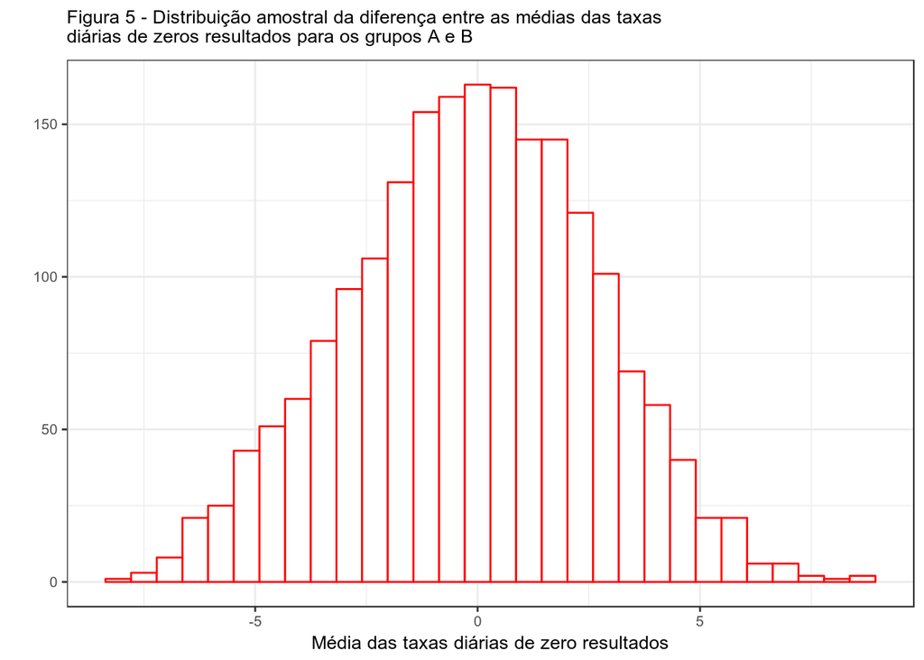

```r
tibble(estatistica = as.double(bootstraps$t)) %>%
  ggplot(aes(x = estatistica)) +
  geom_histogram(fill = "white", color = "red") +
  ggtitle("Figura 5 - Distribuição amostral da diferença entre as médias das taxas\ndiárias de zeros resultados para os grupos A e B") +
  ylab(" ") +
  xlab("Média das taxas diárias de zero resultados") +
  theme(text = element_text(family = "Arial", size = 10), plot.title = element_text(size = 10), axis.title.x = element_text(size = 10), axis.title.y = element_text(size = 10))
```

```r
boot.ci(bootstraps, conf = 0.95, type = "perc")
```

```
## BOOTSTRAP CONFIDENCE INTERVAL CALCULATIONS
## Based on 2000 bootstrap replicates
##
## CALL :
## boot.ci(boot.out = bootstraps, conf = 0.95, type = "perc")
##
## Intervals :
## Level     Percentile
## 95%   (-5.5938,  5.1459 )
## Calculations and Intervals on Original Scale
```

**Observação importante!** Os resultados apresentados neste relatório diferem daqueles exibidos no Relatório do Lab 3 - *Checkpoint* 1, em relação à primeira pergunta, pois o tamanho da amostra considerado no processo de *bootstraping* foi diferente (40 observações x 1000 observações consideradas neste relatório). Observou-se que o tamanho da amostra influenciou no cálculo do intervalo de confiança para a diferença entre as médias de taxas diárias de *clickthrough* entre os grupos A e B, no Relatório anterior, de forma a influenciar diretamente as conclusões sobre o teste A/B. Assim, este erro foi corrigido neste relatório!